# HW2: PCA

## Image 2

### Read in data

```r
x <- read_csv("data/image2.csv")
x <- data.matrix(x)
```

### Original and first 10 k’s

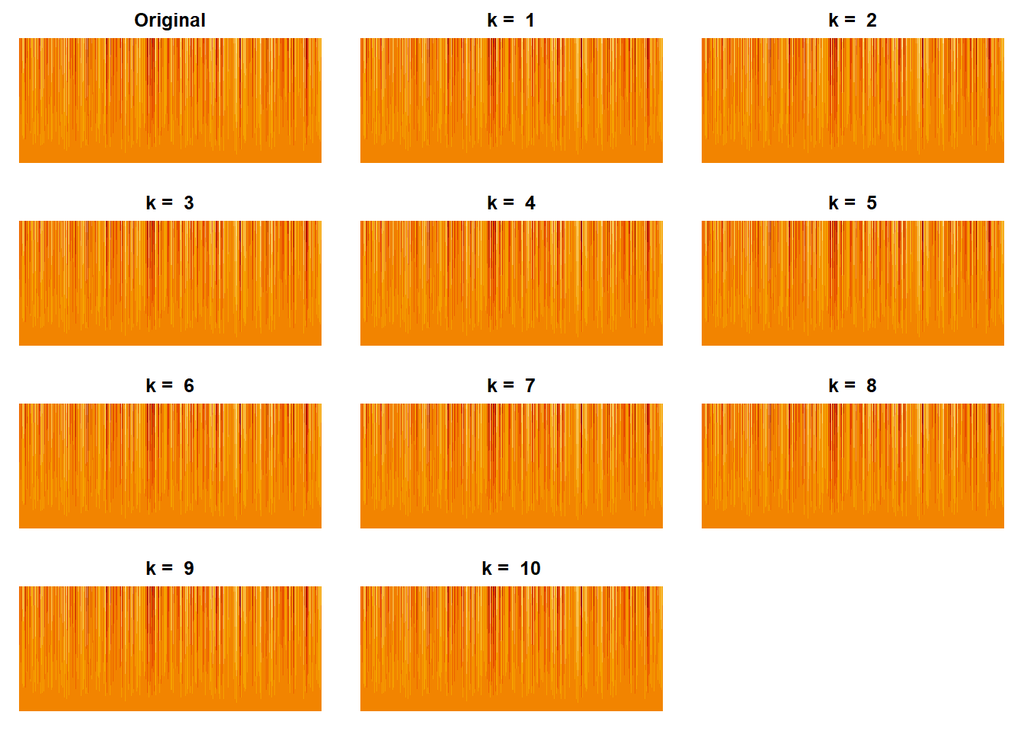

```r
ks = 1:10
all_approx = vector("list", 10)
for(i in ks){
  comp = compress(x, i)
  all_approx[[i]] = comp$approx
}

par(mfrow = c(4, 3), mar = c(1,1,2,1))
image(x, main = "Original", axes = F)
for(i in ks){
  image(all_approx[[i]], main = paste("k = ", i), axes = F)
}
```

### Error vs. k’s

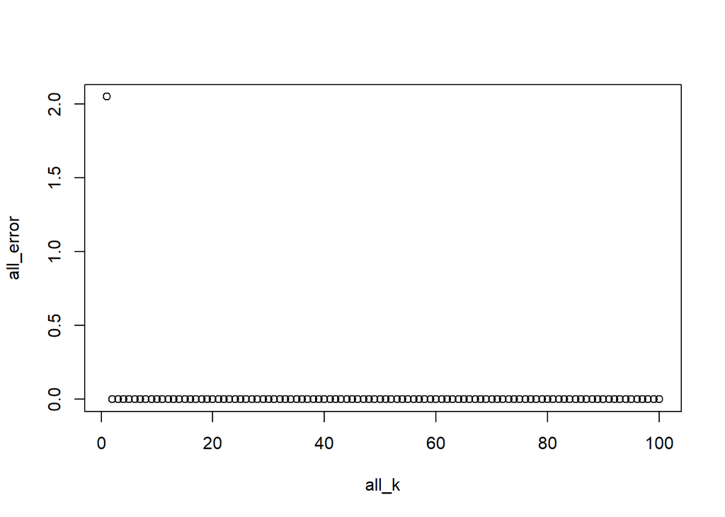

```r
p = dim(x)[2]
all_k = 1:p
all_error = numeric(p)
for(i in all_k){
  comp = compress(x, i)
  all_error[i] = comp$error
}

plot(all_k, all_error)
```

### First Eigenvalues and PC Scores

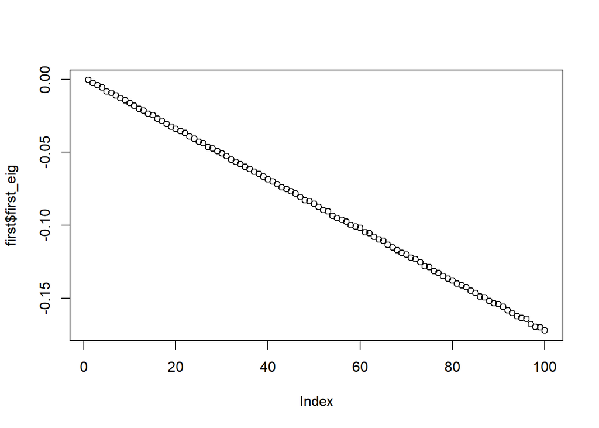

```r
first = compress(x, 1)
plot(first$first_eig)
```

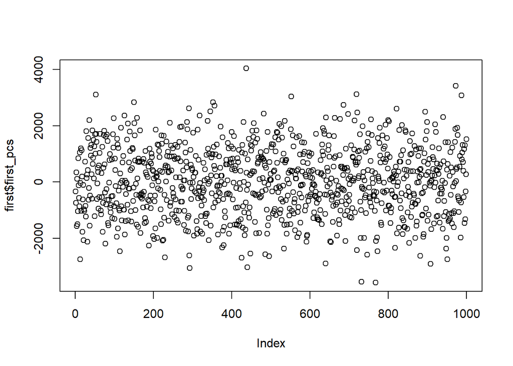

```r
plot(first$first_pcs)
```

## Image 3

### Read in data

```r
x <- read_csv("data/image3.csv")
x <- data.matrix(x)
```

### Original and first 10 k’s

[figure not shown]

```r
ks = 1:10
all_approx = vector("list", 10)
for(i in ks){
  comp = compress(x, i)
  all_approx[[i]] = comp$approx
}

par(mfrow = c(4, 3), mar = c(1,1,2,1))
image(x, main = "Original", axes = F)
for(i in ks){
  image(all_approx[[i]], main = paste("k = ", i), axes = F)
}
```

### Error vs. k’s

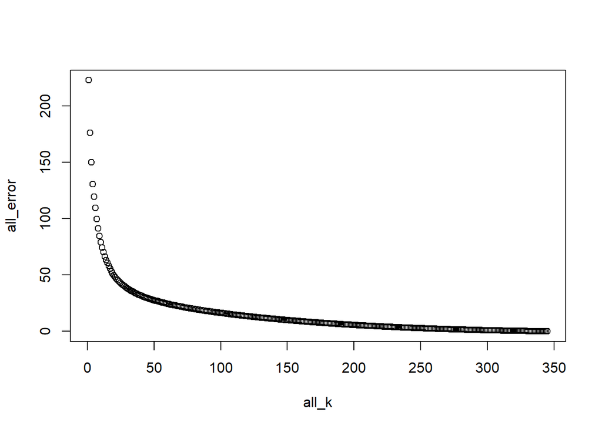

```r
p = dim(x)[2]
all_k = 1:p
all_error = numeric(p)
for(i in all_k){
  comp = compress(x, i)
  all_error[i] = comp$error
}

plot(all_k, all_error)
```

### First Eigenvalues and PC Scores

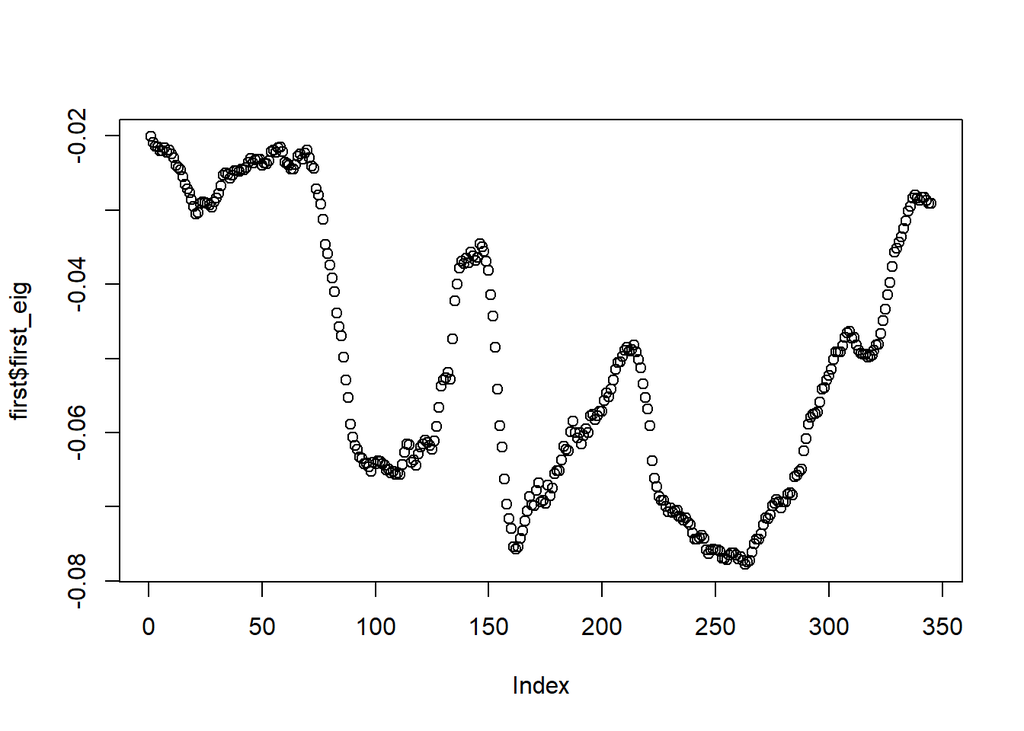

```r
first = compress(x, 1)
plot(first$first_eig)
```

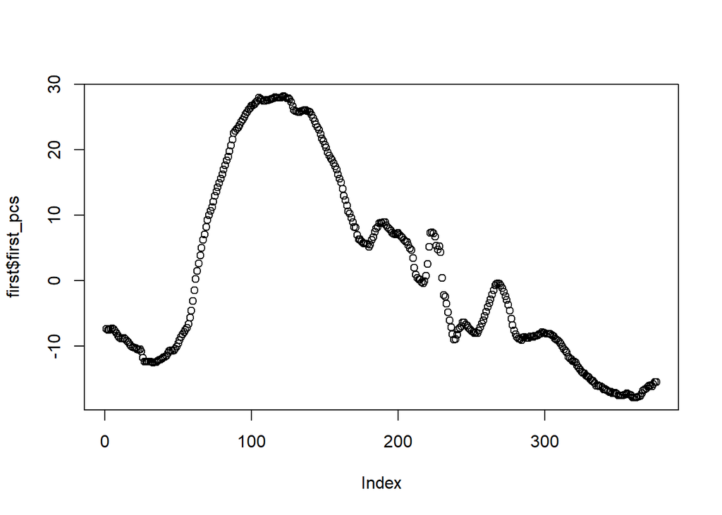

```r
plot(first$first_pcs)
```

### Which k is “sufficient”?

Looking at the error vs. k graph we can see an elbow of the curve that tells us that anything beyond the elbow decreases in the amount the error is reduced. The elbow is typically a nice fair point for a sufficiently good approximation. In this case, I think a k=20 is a sufficiently good approximation of the original image.

## Image 4

### Read in data

```r
x <- read_csv("data/image4.csv")
x <- data.matrix(x)
```

### Original and first 10 k’s

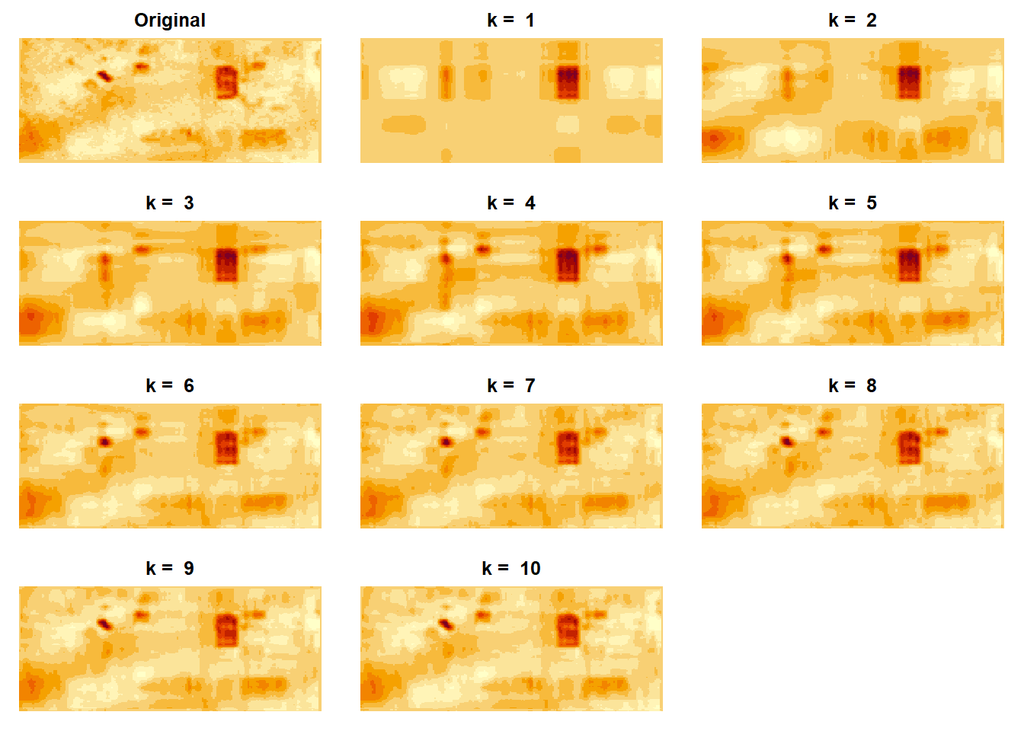

```r
ks = 1:10
all_approx = vector("list", 10)
for(i in ks){
  comp = compress(x, i)
  all_approx[[i]] = comp$approx
}

par(mfrow = c(4, 3), mar = c(1,1,2,1))
image(x, main = "Original", axes = F)
for(i in ks){
  image(all_approx[[i]], main = paste("k = ", i), axes = F)
}
```

### Error vs. k’s

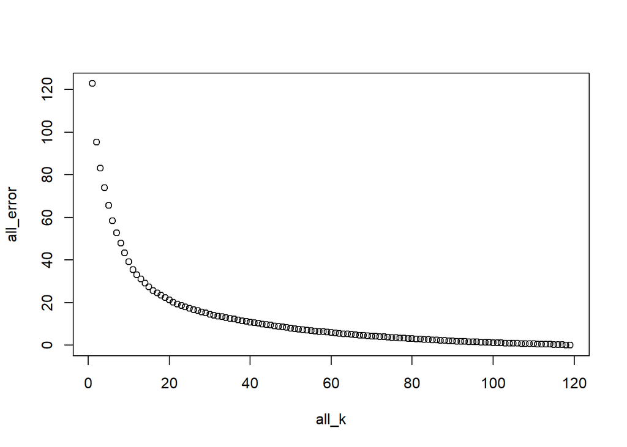

```r
p = dim(x)[2]
all_k = 1:p
all_error = numeric(p)
for(i in all_k){
  comp = compress(x, i)
  all_error[i] = comp$error
}

plot(all_k, all_error)
```

### First Eigenvalues and PC Scores

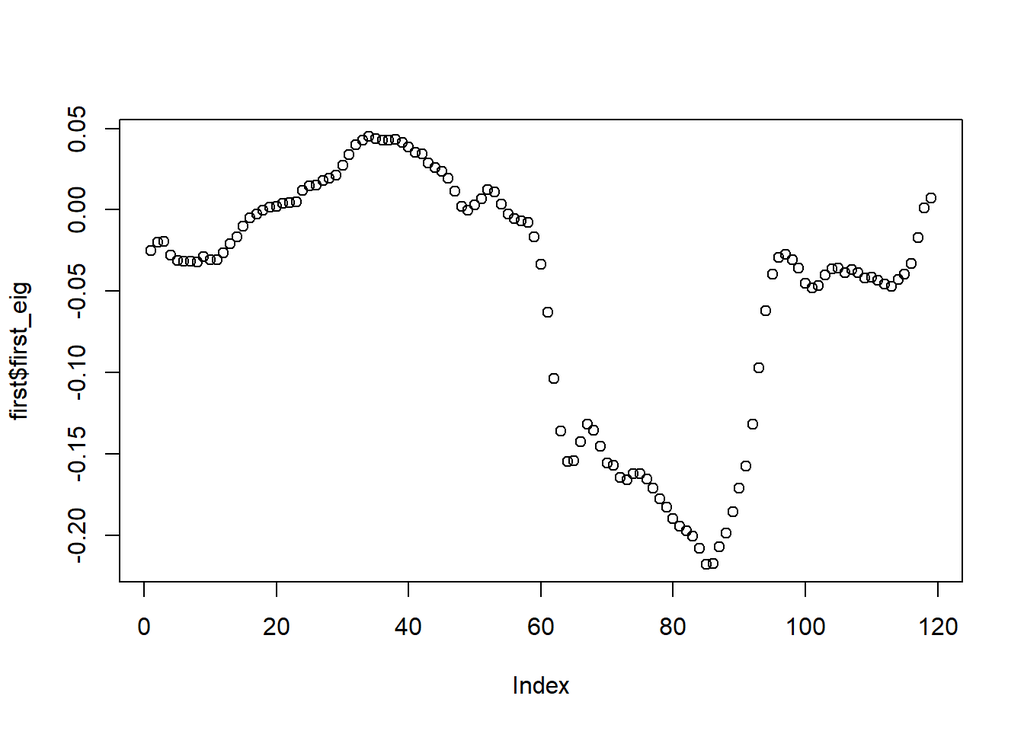

```r
first = compress(x, 1)
plot(first$first_eig)
```

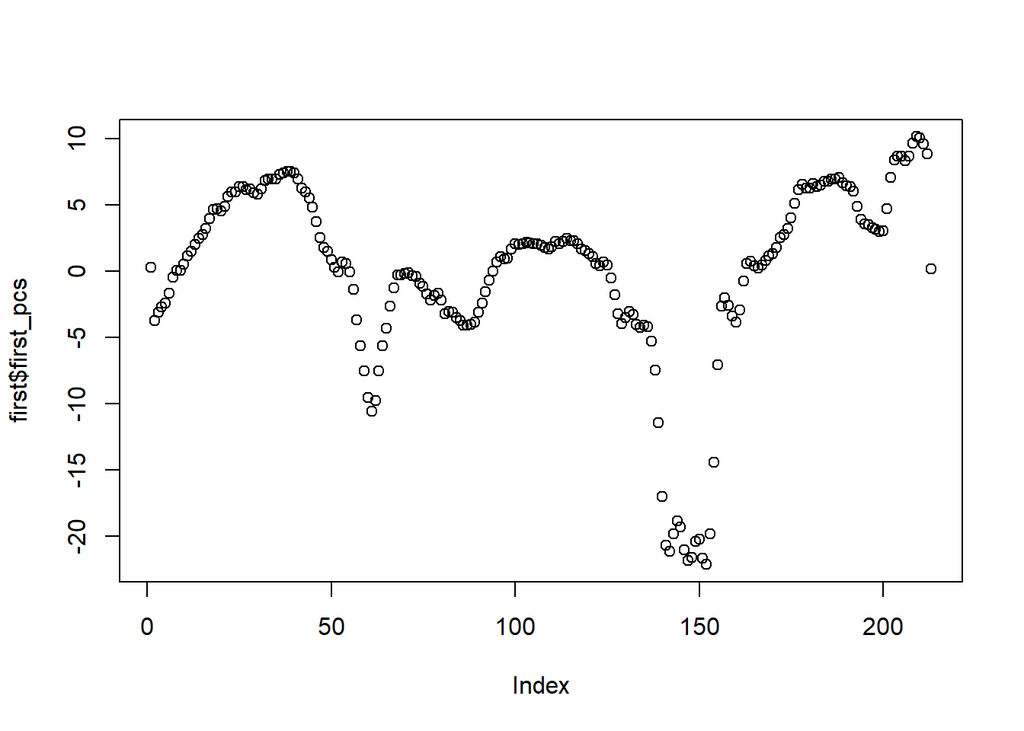

```r
plot(first$first_pcs)
```

### Which k is “sufficient”?

Looking at the error vs. k graph we can see an elbow of the curve that tells us that anything beyond the elbow decreases in the amount the error is reduced. The elbow is typically a nice fair point for a sufficiently good approximation. In this case, I think a k=12 is a sufficiently good approximation of the original image.